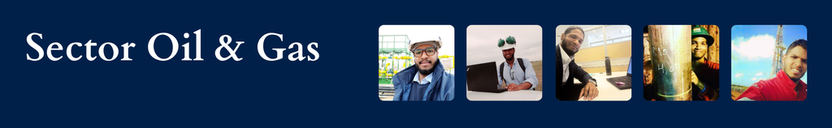

### **Inspector General de Obra | Inspector de Calidad Oil & Gas**

#### **Bureau Veritas**

##### Buenos Aires

##### 2023 - 2025

- Inspeccioné en campo las fases constructivas de la Planta Compresora de Gas Mercedes, asegurando el cumplimiento de las actividades con base a planos, procedimientos y especificaciones técnicas lo que contribuyó a mantener la calidad y la seguridad.
- Desarrollé un sistema de gestión en Excel para el seguimiento y control de registros de liberación y conformidad en los hitos de construcción de la planta, asegurando la disponibilidad y trazabilidad documental en las distintas disciplinas.
- Efectué vuelos con dron DJI Mini 2 para relevamiento fotográfico y seguimiento de avance del proyecto. Implementé esta metodología como una nueva herramienta para optimizar el seguimiento y control del proyecto.
- Realicé inspecciones en múltiples talleres industriales para verificar avances en elementos constructivos críticos, para asegurar la conformidad de las especificaciones técnicas antes de su instalación en campo.
- Gestioné documentación técnica y administrativa, brindé soporte logístico para el equipo de inspección y asistí en la elaboración de informes de gestión de la jefatura de inspección cumpliendo los plazos establecidos.

### **Administrativo de Obra Oil & Gas**

#### **Bureau Veritas**

##### Buenos Aires

##### Nov. 2022 - Jul. 2023

- Gestioné documentación técnica y administrativa, brindé soporte logístico para el equipo de inspección y asistí en la elaboración de informes de gestión de la jefatura de inspección cumpliendo los plazos establecidos.

### **Ingeniero Analista | Gestor de Proyectos**

#### **Viceministerio de Gas**

##### Caracas

##### 2015 - 2022

- Gestioné proyectos corporativos del Viceministerio mediante metodología waterfall, liderando la elaboración de manuales, programas de estandarización de procesos administrativos que brindaron optimización en la gestión institucional.
- Coordiné aproximadamente 20 profesionales de la Dirección General. Asignando y supervisando las actividades de los equipos, cronogramas y facilitando reuniones, logrando un 95% de cumplimiento en los objetivos anuales establecidos.
- Actué como enlace con entidades del sector, incluyendo la organización del Foro de Países Exportadores de Gas. Coordiné reuniones de trabajo con las partes interesadas (stakeholders) del ámbito local e internacional contribuyendo al éxito de varias iniciativas.
- Evalué y realicé el seguimiento técnico-administrativo de los Planes de Producción y Trabajo Anual de cuatro empresas licenciatarias de gas natural, asegurando el cumplimiento de los planes, normativas y ejecución de los proyectos establecidos.
- Realicé visitas técnicas de inspección a más de 30 instalaciones de superficie a nivel nacional para la verificación de condiciones operacionales y volumetrías de gas, avances de construcciones de infraestructuras y actividades aprobadas en los Planes de Trabajo.
- Desarrollé y presenté informes ejecutivos y cuadros de mando (dashboards) con indicadores clave de desempeño (KPIs) para la alta gerencia, facilitando la toma de decisiones estratégicas y el seguimiento de objetivos.
- Representé a la institución en el Biogas Institute of Ministry of Agriculture and Rural Affairs de China (Chengdu), obteniendo el segundo lugar en la presentación del Country Report entre 42 países participante.

### **Ingeniero de Campo | Perforación**

#### **Halliburton**

##### Maturín & Anzoátegui

##### 2012 - 2014

- Ejecuté y supervisé la perforación direccional de pozos horizontales en la Faja Petrolífera del Orinoco (FPO), asegurando el cumplimiento de las trayectorias planificadas a través de la supervisión de los parámetros de perforación.
- Coordiné la integración técnica y operativa en tiempo real con los equipos de Well Planning, MWD/LWD, geología y supervisores de pozos durante las fases de perforación, incluyendo construcción de ángulos (Build-Up), aterrizaje en el yacimiento (Landing) y navegación en la sección horizontal.
- Utilicé software OpenWells® para el seguimiento y reporte de las operaciones de la perforación direccional.
- Elaboré informes técnicos para empresas operadoras clientes sobre el avance de perforación, desempeño de herramientas y cumplimiento de objetivos operacionales.
- Desarrollé el Manual de Perforación de Pozos Horizontales en el Campo Huyaparí de la FPO (PDVSA PETROPIAR), estableciendo directrices para optimizar operaciones, eficiencia y seguridad. El proyecto obtuvo la máxima calificación académica y Mención Honorífica.

[**Manual de Perforación**](http://saber.ucv.ve/handle/10872/2873)

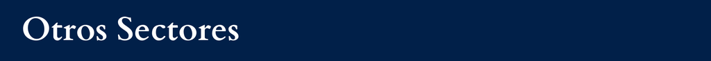

### **Ingeniero Analista**

#### **RESQUIMC**

##### Caracas

##### 2014 - 2015

- Desarrollé instrumentos técnicos - administrativos (manuales,guía, formatos) para el control de las actividades de inspección y relevamiento de información de las empresas Licenciadas. Adicional, generé informes técnicos y documentación administrativa para el análisis de las solicitudes de trámites regulatorios inherentes a sustancias químicas controladas.
- Inspeccioné las empresas licenciadas para el uso lícito de las sustancias químicas controladas.
- Participé en la gestión de proyectos internos de la Dirección.
- Culminé la Diplomatura sobre Estudios Avanzados en Prevención del Desvío de Sustancias Químicas Controladas, impartida por la Oficina Nacional Antidroga de Venezuela.

### **Representante Comercial | Freelance**

#### **AUDIO DIGITAL 34 - EQUIPOS DE AUDIO Y VÍDEO PROFESIONAL**

##### Caracas

##### 2014 - 2016

- Estrategias de ventas de los servicios de alquiler de equipos de audios y vídeos profesional para eventos.
- Elaboración de propuestas comerciales.
- Prospección, visita y seguimiento de clientes en el área de organizaciones y eventos privados.